# Introducción a MatplotLib

[Matplotlib](https://matplotlib.org) es una biblioteca que permite la creación de figuras y gráficos de calidad mediante el uso de Python.

- Permite la creación de gráficos de manera sencilla y eficiente.
- Permite la integración de gráficos y figuras en un Jupyter Notebook.

## Import

```python
import matplotlib
import matplotlib.pyplot as plt
```

```python
# Muestra los gráficos integrados dentro de Jupyter Notebook
%matplotlib inline
```

## Representación gráfica de Datos.

Si a la función de trazado se le da una matriz de datos, la usará como coordenadas en eje vertical, y utilizará el índice de cada punto de datos en el array como la coordenada horizontal.

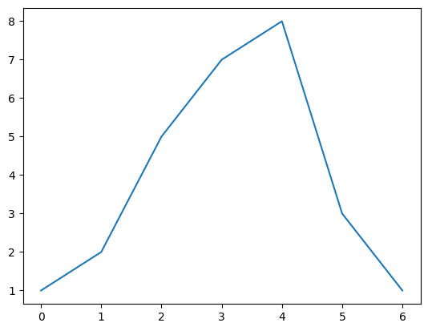

```python
plt.plot([1, 2, 5, 7, 8, 3, 1])
plt.show()
```

Tambien se puede proporcionar dos matrices: una para el eje horizontal, y otra para el eje vertical.

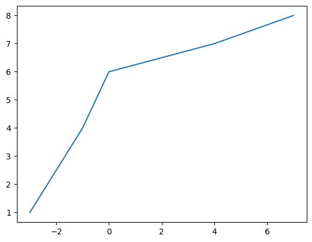

```python
plt.plot([-3, -1, 0, 4, 7], [1, 4, 6, 7, 8])
plt.show()
```

Pueden modificarse las longitudes de los ejes para que la figura no se vea tan ajustada.

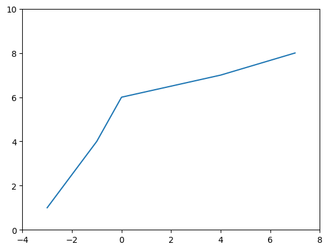

```python
plt.plot([-3, -1, 0, 4, 7], [1, 4, 6, 7, 8])
plt.axis([-4, 8, 0, 10]) # [xmin, xmax, ymin, ymax]
plt.show()
```

Se sigue el mismo procedimiento para pintar una función matemática.

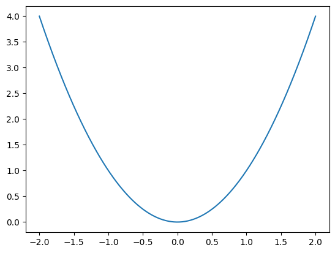

```python
import numpy as np
x = np.linspace(-2, 2, 500)
y = x**2

plt.plot(x, y)
plt.show()
```

Tambien puede modificarse el estilo de la gráfica para que contenga más información.

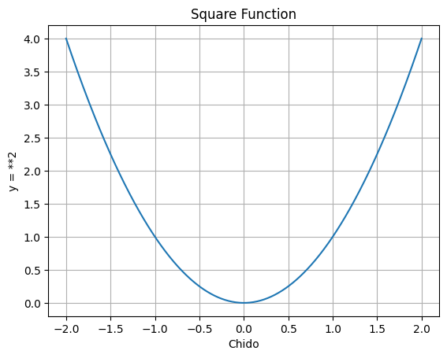

```python
plt.plot(x, y)
plt.title("Square Function")
plt.xlabel("Chido")
plt.ylabel("y = **2")
plt.grid(True)
plt.show()
```

Pueden superponerse gráficas y cambiar el estilo de las funciones.

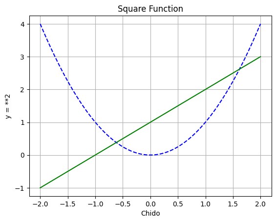

```python
import numpy as np
x = np.linspace(-2, 2, 500)
y = x**2
y2 = x + 1

plt.title("Square Function")
plt.xlabel("Chido")
plt.ylabel("y = **2")
plt.grid(True)

plt.plot(x, y, 'b--', x, y2, 'g')
plt.show()
```

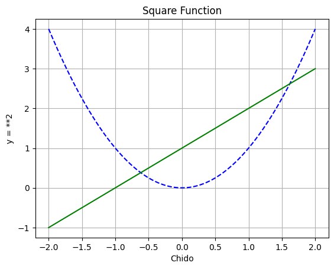

```python
# Separando en diferentes lineas las funciones.
import numpy as np
x = np.linspace(-2, 2, 500)
y = x**2
y2 = x + 1

plt.title("Square Function")
plt.xlabel("Chido")
plt.ylabel("y = **2")
plt.grid(True)

plt.plot(x, y, 'b--')
plt.plot(x, y2, 'g')
plt.show()
```

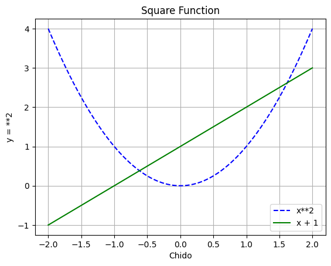

```python
import numpy as np
x = np.linspace(-2, 2, 500)
y = x**2
y2 = x + 1

plt.title("Square Function")
plt.xlabel("Chido")
plt.ylabel("y = **2")
plt.grid(True)

plt.plot(x, y, 'b--', label = "x**2")
plt.plot(x, y2, 'g', label = "x + 1")
plt.legend(loc = "best") # La situa en la mejor localización
plt.show()
```

Tambien puede crearse dos gráficas que no se superpongan. Estas gráficas se organizan en un grid y se denominan subplots.

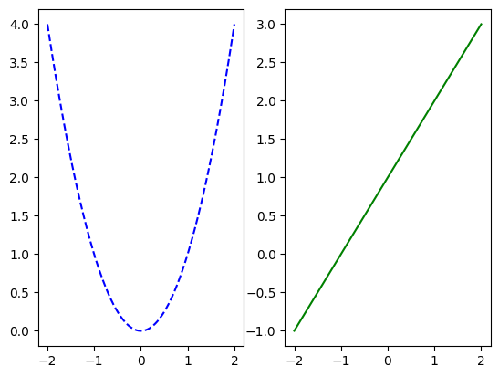

```python
import numpy as np
x = np.linspace(-2, 2, 500)
y = x**2
y2 = x + 1

plt.subplot(1, 2, 1) # 1 Rows, 2 Columns, 1st Subplot
plt.plot(x, y, 'b--')

plt.subplot(1, 2, 2) # 1 Rows, 2 Columns, 2nd Suplots
plt.plot(x, y2, 'g')

plt.show()
```

Para que las gráficas no queden tan ajustadas, se puede hacer la figura ás grande.

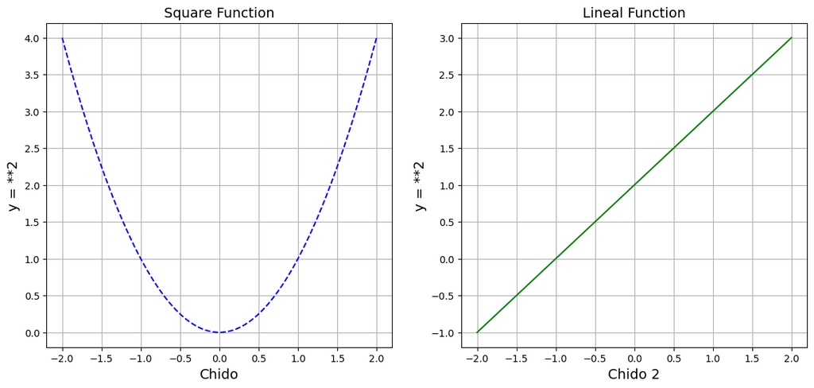

```python
plt.figure(figsize = (14, 6))

plt.subplot(1, 2, 1) # 1 Rows, 2 Columns, 1st Subplot
plt.plot(x, y, 'b--')
plt.title("Square Function", fontsize = 14)
plt.xlabel("Chido", fontsize = 14)
plt.ylabel("y = **2", fontsize = 14)
plt.grid(True)

plt.subplot(1, 2, 2) # 1 Rows, 2 Columns, 2nd Suplots
plt.plot(x, y2, 'g')
plt.title("Lineal Function", fontsize = 14)
plt.xlabel("Chido 2", fontsize = 14)
plt.ylabel("y = **2", fontsize = 14)
plt.grid(True)

plt.show()
```

## Scatter Plots

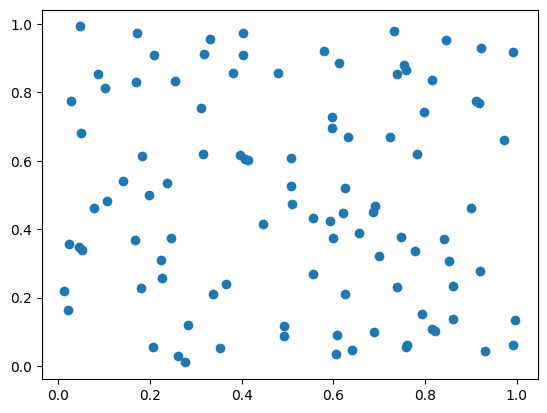

```python
from numpy.random import rand
x, y = rand(2, 100)
plt.scatter(x, y)
plt.show()
```

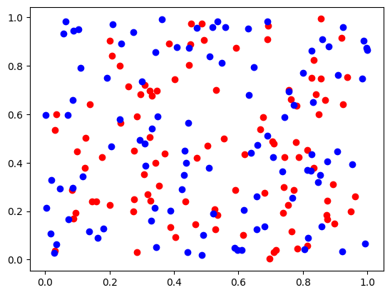

```python
from numpy.random import rand
x, y = rand(2, 100)
x2, y2 = rand(2, 100)
plt.scatter(x, y, c = 'red')
plt.scatter(x2, y2, c = 'blue')
plt.show()
```

## Histogramas

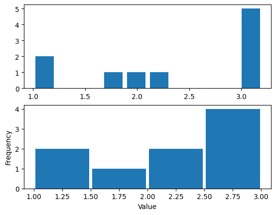

```python
data = [1, 1.1, 1.8, 2, 2.1, 3.2, 3, 3, 3, 3]
plt.subplot(211)
plt.hist(data, bins = 10, rwidth = 0.8)

plt.subplot(212)
plt.hist(data, bins = [1, 1.5, 2, 2.5, 3], rwidth = 0.95)
plt.xlabel('Value')
plt.ylabel('Frequency')

plt.show()
```

## Guardar las figuras

```python
from numpy.random import rand
x, y = rand(2, 100)
x2, y2 = rand(2, 100)
plt.scatter(x, y, c = 'red')
plt.scatter(x2, y2, c = 'blue')

plt.savefig("3501_Mi_Grafica_Chida.png", transparent = True)
```